# R Notebook

```r
library(rpart)
library(rpart.plot)
library(tidyverse)

library(tidyverse)
titanic_set <- read_csv('data/titanic_decision_tree_data.csv')

shuffle_index <- sample(1:nrow(titanic_set))

# shuffle the data so class order isn't in order - need this for training/testing split later on
titanic_set <- titanic_set[shuffle_index, ]
```

# 1 MVP

1.1 Question 1

Cleaning up the data is always the first step. Do the following:

Take only observations which have a survived flag (i.e. that aren’t missing) Turn your important variables into factors (sex, survived, pclass, embarkation) Create an age_status variable which groups individuals under (and including) 16 years of age into a category called “child” category and those over 16 into a category called “adult”. Drop the NA Drop any variables you don’t need (X1, passenger_id, name, ticket, far, cabin) If you need help doing this, the code is below, but please try it yourself first so you can learn!

```r
head(titanic_set)
```

| X1 | passenger_id | pclass | name | sex | age | sib_sp | parch | ticket | fare | cabin | embarked | survived |
| --- | --- | --- | --- | --- | --- | --- | --- | --- | --- | --- | --- | --- |
| 588 | 170 | 3 | Ling, Mr. Lee | male | 28 | 0 | 0 | 1601 | 56.4958 | NA | S | 0 |
| 780 | 362 | 2 | del Carlo, Mr. Sebastiano | male | 29 | 1 | 0 | SC/PARIS 2167 | 27.7208 | NA | C | 0 |
| 1284 | 866 | 2 | Bystrom, Mrs. (Karolina) | female | 42 | 0 | 0 | 236852 | 13.0000 | NA | S | 1 |
| 465 | 47 | 3 | Lennon, Mr. Denis | male | NA | 1 | 0 | 370371 | 15.5000 | NA | Q | 0 |
| 1289 | 871 | 3 | Balkic, Mr. Cerin | male | 26 | 0 | 0 | 349248 | 7.8958 | NA | S | 0 |
| 404 | 1295 | 1 | Carrau, Mr. Jose Pedro | male | 17 | 0 | 0 | 113059 | 47.1000 | NA | S | NA |

```r
summary(titanic_set)
```

```
       X1        passenger_id      pclass          name               sex
 Min.   :   1   Min.   :   1   Min.   :1.000   Length:1309        Length:1309
 1st Qu.: 328   1st Qu.: 328   1st Qu.:2.000   Class :character   Class :character
 Median : 655   Median : 655   Median :3.000   Mode  :character   Mode  :character
 Mean   : 655   Mean   : 655   Mean   :2.295
 3rd Qu.: 982   3rd Qu.: 982   3rd Qu.:3.000
 Max.   :1309   Max.   :1309   Max.   :3.000

      age            sib_sp           parch          ticket               fare
 Min.   : 0.17   Min.   :0.0000   Min.   :0.000   Length:1309        Min.   :  0.000
 1st Qu.:21.00   1st Qu.:0.0000   1st Qu.:0.000   Class :character   1st Qu.:  7.896
 Median :28.00   Median :0.0000   Median :0.000   Mode  :character   Median : 14.454
 Mean   :29.88   Mean   :0.4989   Mean   :0.385                      Mean   : 33.295
 3rd Qu.:39.00   3rd Qu.:1.0000   3rd Qu.:0.000                      3rd Qu.: 31.275
 Max.   :80.00   Max.   :8.0000   Max.   :9.000                      Max.   :512.329
 NA's   :263                                                         NA's   :1
    cabin             embarked            survived
 Length:1309        Length:1309        Min.   :0.0000
 Class :character   Class :character   1st Qu.:0.0000
 Mode  :character   Mode  :character   Median :0.0000
                                       Mean   :0.3838
                                       3rd Qu.:1.0000
                                       Max.   :1.0000
                                       NA's   :418
```

```r
unique(titanic_set$pclass)
```

```
[1] 3 2 1
```

```r
titanic_clean <- titanic_set %>%
  #select(-c("X1", "passenger_id", "name", "ticket", "fare", "cabin")) %>%
  filter(!is.na(survived)) %>%
  mutate(sex = as.factor(sex),
         survived = factor(survived, levels = c(0, 1), labels = c("No", "Yes")),
         class = factor(pclass, levels = c(1, 2, 3), labels = c("Upper", "Middle", "Lower")),
         embarkation = factor(embarked, levels = c("C", "Q", "S"), labels = c("Cherbourg", "Queenstown", "Southampton"))
         ) %>%
  mutate(age_status = as.factor(if_else(age <= 16, "Child", "Adult"))) %>%
  select(sex, age_status, class, embarkation, sib_sp, parch, survived) %>%
  na.omit()


head(titanic_clean)
```

| sex | age_status | class | embarkation | sib_sp | parch | survived |
| --- | --- | --- | --- | --- | --- | --- |
| male | Adult | Lower | Southampton | 0 | 0 | No |
| male | Adult | Middle | Cherbourg | 1 | 0 | No |
| female | Adult | Middle | Southampton | 0 | 0 | Yes |
| male | Adult | Lower | Southampton | 0 | 0 | No |
| male | Adult | Lower | Southampton | 0 | 0 | No |
| male | Adult | Lower | Southampton | 0 | 0 | Yes |

```r
NA
```

Question 2

Have a look at your data and create some plots to ensure you know what you’re working with before you begin. Write a summary of what you have found in your plots. Which variables do you think might be useful to predict whether or not people are going to die? Knowing this before you start is the best way to have a sanity check that your model is doing a good job.

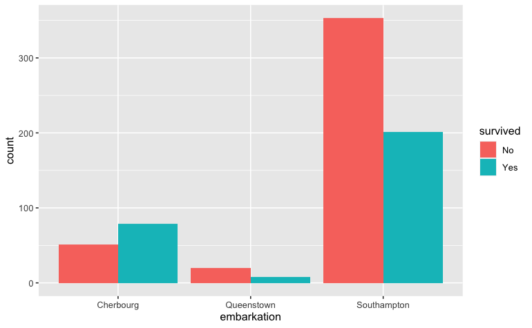

```r
titanic_clean %>%
  #group_by(embarkation) %>%
  ggplot() +
  geom_bar(aes(x = embarkation, fill = survived), position = "dodge")
```

```r
NA
NA
NA
```

Predictors selection

Question 3

Now you can start to build your model. Create your testing and training set using an appropriate split. Check you have balanced sets. Write down why you chose the split you did and produce output tables to show whether or not it is balanced.

```r
# get how many rows we have in total to work out the percentage
n_data <- nrow(titanic_clean)

# create a test sample index , 80 - 20 split
test_index <- sample(1:n_data, size = n_data*0.20)

# create test set
titanic_test  <- slice(titanic_clean, test_index)

# create training set
titanic_train <- slice(titanic_clean, -test_index)
```

Check that our test and training sets have similar proportions of survivors. Use janitor::tabyl() for calculating tables.

```r
titanic_test %>%
 janitor::tabyl(survived)
```

```
 survived  n  percent
       No 83 0.584507
      Yes 59 0.415493
```

```r
titanic_train %>%
 janitor::tabyl(survived)
```

```
 survived   n   percent
       No 341 0.5982456
      Yes 229 0.4017544
```

This seems like a pretty even split!

Question 4

Create your decision tree to try and predict survival probability using an appropriate method, and create a decision tree plot.

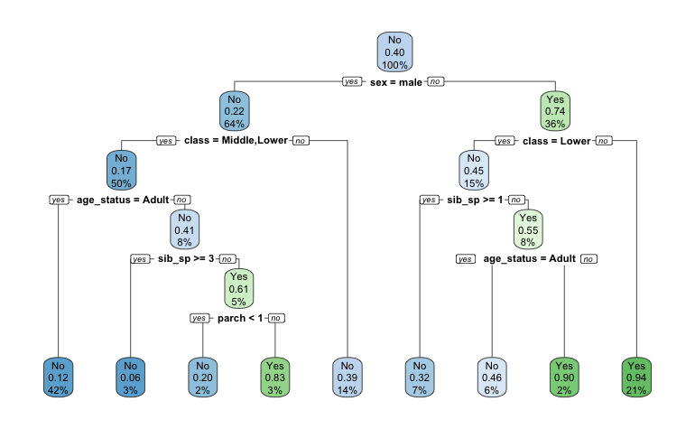

```r
titanic_fit <- rpart(survived ~ .,
                     data = titanic_train,
                     method = 'class')

rpart.plot(titanic_fit, yesno = 2)
```

Rules used to make the tree:

```r
rpart.rules(titanic_fit, cover = TRUE)
```

|  | survived |  |  |  |  |  |  |  |  |  |  |  |  |  |  |  |  |  |  |  |  | cover |
| --- | --- | --- | --- | --- | --- | --- | --- | --- | --- | --- | --- | --- | --- | --- | --- | --- | --- | --- | --- | --- | --- | --- |
| 18 | 0.06 | when | sex | is | male | & | class | is | Middle or Lower | & | sib_sp | >= | 3 | & | age_status | is | Child |  |  |  |  | 3% |
| 8 | 0.12 | when | sex | is | male | & | class | is | Middle or Lower |  |  |  |  | & | age_status | is | Adult |  |  |  |  | 42% |
| 38 | 0.20 | when | sex | is | male | & | class | is | Middle or Lower | & | sib_sp | < | 3 | & | age_status | is | Child | & | parch | < | 1 | 2% |
| 12 | 0.32 | when | sex | is | female | & | class | is | Lower | & | sib_sp | >= | 1 |  |  |  |  |  |  |  |  | 7% |
| 5 | 0.39 | when | sex | is | male | & | class | is | Upper |  |  |  |  |  |  |  |  |  |  |  |  | 14% |
| 26 | 0.46 | when | sex | is | female | & | class | is | Lower | & | sib_sp | < | 1 | & | age_status | is | Adult |  |  |  |  | 6% |
| 39 | 0.83 | when | sex | is | male | & | class | is | Middle or Lower | & | sib_sp | < | 3 | & | age_status | is | Child | & | parch | >= | 1 | 3% |
| 27 | 0.90 | when | sex | is | female | & | class | is | Lower | & | sib_sp | < | 1 | & | age_status | is | Child |  |  |  |  | 2% |
| 7 | 0.94 | when | sex | is | female | & | class | is | Upper or Middle |  |  |  |  |  |  |  |  |  |  |  |  | 21% |

Use trained model to create predictions on test dataset

```r
library(modelr)

# add the predictions
titanic_test_pred <- titanic_test %>%
                 add_predictions(titanic_fit, type = 'class')
```

Question 6

Test and add your predicitons to your data. Create a confusion matrix. Write down in detial what this tells you for this specific dataset. Look at the predictions

```r
# look at the variables
titanic_test_pred %>%
  select(sex, age_status, class, embarkation, sib_sp, parch, pred)
```

| sex | age_status | class | embarkation | sib_sp | parch | pred |
| --- | --- | --- | --- | --- | --- | --- |
| male | Adult | Upper | Southampton | 0 | 0 | No |
| male | Adult | Lower | Southampton | 0 | 0 | No |
| female | Adult | Upper | Southampton | 1 | 2 | Yes |
| female | Child | Lower | Southampton | 4 | 2 | No |
| female | Child | Middle | Cherbourg | 1 | 0 | Yes |
| male | Adult | Lower | Southampton | 0 | 0 | No |
| male | Child | Lower | Queenstown | 4 | 1 | No |
| male | Adult | Lower | Cherbourg | 1 | 0 | No |
| male | Adult | Upper | Southampton | 1 | 4 | No |
| male | Adult | Lower | Southampton | 0 | 0 | No |

[output cut: 132 more lines]

Checking model performance using Confusion Matrix

```r
library(yardstick)

confusion_matrix <- titanic_test_pred %>%
              conf_mat(truth = survived, estimate = pred)

confusion_matrix
```

```
          Truth
Prediction No Yes
       No  79  21
       Yes  4  38
```

Find accuracy of the model:

```r
accuracy <- titanic_test_pred %>%
 accuracy(truth = survived, estimate = pred)

accuracy
```

| .metric | .estimator | .estimate |
| --- | --- | --- |
| accuracy | binary | 0.8239437 |

The probability of correctly predicting whether or not a passenger on the titanic will survive is 0.82